# BASEN

Heewon Seo

March 11, 2026

Abstract

Comparing taxonomic abundance across long-read metagenomic samples is challenging because abundance summaries can be influenced by sequencing depth, read-length variation, taxonomic assignment characteristics, and reference genome size. In Oxford Nanopore data, broad read-length distributions further complicate the interpretation of count-based summaries. BASEN is a framework for species-level abundance estimation from Kraken2 outputs that aggregates species-assigned k-mer evidence, normalizes this signal by effective reference genome length, and generates genome-size-aware relative abundance estimates. BASEN also provides read-level compositional quality-control metrics, including assigned and unassigned k-mer proportions and Shannon diversity of k-mer assignments, to support identification of low-information reads. Together, these features improve the robustness and interpretability of species-level abundance estimates in long-read metagenomic analyses.

# Overview

BASEN (**B**ase-level **A**bundance estimation with **S**pecies-assigned **E**vidence using **N**anopore) computes genome-size-normalized, species-level relative abundance from Kraken2 classification outputs. BASEN aggregates species-assigned k-mer evidence across classified reads, normalizes the resulting signal by effective reference genome length, and scales the normalized values within each sample to produce relative abundance estimates. In addition, BASEN provides read-level k-mer composition metrics that support compositional quality control prior to abundance estimation. This vignette demonstrates a typical BASEN workflow using example files shipped with the package under `inst/testdata`.

# Workflow

## 0. Preparation

### A. Construct a custom database

- To ensure correct taxonomic assignment, reference genome FASTA headers should include a Kraken2-recognizable TaxID in the following format:

```bash
|kraken:taxid|XXXXXX
```

- An example workflow for building a custom Kraken2 database is shown below.

```bash
# Do not run
k2 download-taxonomy --db MYCUSTOM
k2 add-to-library --file XXXXXX.fasta --db MYCUSTOM
k2 build --db MYCUSTOM
```

### B. Run Kraken2 classification

- Run Kraken2 using the custom database and generate both `.report` and `.kraken` output files for each sample.

```bash
# Do not run
export DB_DIR=/path/to/MYCUSTOM
export PROJECT=/path/to/PROJECT
export FASTQ_DIR=/path/to/FASTQ

k2 classify \
  --db $DB_DIR \
  --report $PROJECT/REPORT/SAMPLE_x.report \
  --output $PROJECT/KRAKEN/SAMPLE_x.kraken \
  $FASTQ_DIR/SAMPLE_x.fastq.gz
```

### C. Generate genome size statistics

- BASEN requires genome size information for abundance normalization. The auxiliary script `get_genome_length_from_fasta.sh`, located under `inst/scripts`, can be used to extract genome lengths directly from FASTA files.
- The script outputs a tab-delimited file without a header, containing the following columns:
  1. `TaxID`
  2. `Total genome length in base pairs`
  3. `Accession`
  4. `Description`
- Only the first two columns, TaxID and total genome length, are required by BASEN.

```bash
sh get_genome_length_from_fasta.sh *.fa > genome_size.txt
```

## 1. Read-level compositional quality control

Long-read taxonomic assignments can be ambiguous. Before quantifying sample-level abundance, BASEN can profile the k-mer composition of individual reads to identify low-information classifications and define empirical filtering thresholds.

### A. Load the package and example paths

- First, load the packages and define the absolute paths to your Kraken classification files and genome size statistics.

```r
library(basen)
library(data.table)
library(ggplot2)

kraken_dir <- system.file("testdata", package = "basen")
genome_stats_file <- system.file(
  "testdata", "example_genome_size.txt",
  package = "basen"
)
```

### B. Profile k-mer composition for a single sample

- The `profile_kmer_composition()` function parses a Kraken2 `*.kraken` file and computes per-read metrics, including total k-mers, assigned k-mers, unassigned k-mers, assigned and unassigned proportions, and Shannon diversity of the k-mer assignment profile.

```r
kraken_file <- file.path(kraken_dir, "exampleA.kraken")

qc_metrics <- profile_kmer_composition(
  kraken_file = kraken_file,
  k_mer_length = 35
)
```

```
#> Execution statistics for profile_kmer_composition:
#> Number of files read: 1
#> Total reads processed: 126
#> Classified reads profiled: 121
```

```r
head(qc_metrics)
```

```
#>                                 read_id total_kmers assigned_kmers
#>                                  <char>       <num>          <num>
#> 1: 0405fcde-d9cd-4b6d-b652-76d96556d7f1         250            132
#> 2: 9053d466-8b23-4314-a095-9581f4b137a9          86             32
#> 3: bafe8b8a-6cbd-4b2d-b54f-bb13d7f10894         260             11
#> 4: 0349d869-ab3e-48e7-a9b0-9c193475d1f8         135             48
#> 5: 4d340d57-b421-458e-a0ab-819f0a891a73         115            107
#> 6: 085c1b93-5ea2-4158-9a4f-c1d5801a890f         298             54
#>    unassigned_kmers kmers_diversity assigned_perc unassigned_perc
#>               <num>           <num>         <num>           <num>
#> 1:              118       0.6915784    0.52800000      0.47200000
#> 2:               54       0.6600602    0.37209302      0.62790698
#> 3:               61       1.1514590    0.04230769      0.23461538
#> 4:                4       0.7710037    0.35555556      0.02962963
#> 5:                8       0.2525128    0.93043478      0.06956522
#> 6:              119       1.5443662    0.18120805      0.39932886
```

### C. Visualize read-level QC diagnostics

- The `plot_kmer_qc()` function generates a two-dimensional binned density plot of unassigned k-mer proportion versus Shannon diversity. Reads with low unassigned proportion and low diversity generally reflect more coherent taxonomic evidence, whereas reads with high unassigned content and diffuse assignments may be less reliable.

```r
qc_plot <- plot_kmer_qc(kmer_profile = qc_metrics)
```

```
#> Execution statistics for plot_kmer_qc:
#> Number of data frames processed: 1
#> Total reads visualized: 121
#> Number of plots generated: 1
```

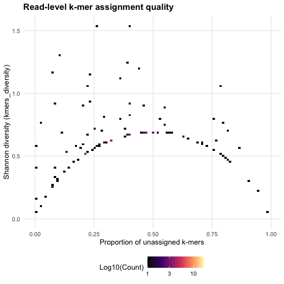

```r
print(qc_plot)
```

### D. Filter low-information reads

- The `filter_low_info_reads()` function applies empirical thresholds to the read-level QC metrics. The `max_unassigned_perc` and `max_shannon_diversity` thresholds are applied jointly: a read is retained only if it satisfies both criteria.

```r
hq_reads_exampleA <- filter_low_info_reads(
  kmer_profile = qc_metrics,
  max_unassigned_perc = 0.5,
  max_shannon_diversity = 1.0
)
```

```
#> Execution statistics for filter_low_info_reads:
#> Number of samples processed: 1
#> Total reads evaluated: 121
#> Total reads passing filter: 84
```

```r
head(hq_reads_exampleA)
```

```
#> [1] "0405fcde-d9cd-4b6d-b652-76d96556d7f1"
#> [2] "0349d869-ab3e-48e7-a9b0-9c193475d1f8"
#> [3] "4d340d57-b421-458e-a0ab-819f0a891a73"
#> [4] "8b406ab2-4d1d-4b32-8964-bb0893919d01"
#> [5] "99657406-b121-4164-aabc-5d0300766ff3"
#> [6] "8ad58672-1e6a-4ffc-95e0-4e00f4ad3bb2"
```

### E. Profile and compare QC metrics across multiple samples

- To compare read-level QC profiles across a cohort, profile each sample separately, combine the results into a single table, and then apply filtering to the combined object. When a `sample_id` column is present, `filter_low_info_reads()` returns a named list of retained read IDs by sample, which can be passed directly to `kraken_relative_abundance()`.

```r
kraken_files <- list.files(kraken_dir, pattern = "\\.kraken$", full.names = TRUE)

combined_qc <- rbindlist(lapply(kraken_files, function(file) {
  sample_name <- tools::file_path_sans_ext(basename(file))
  metrics <- profile_kmer_composition(
    kraken_file = file,
    k_mer_length = 35
  )
  metrics[, sample_id := sample_name]
  metrics
}))
```

```
#> Execution statistics for profile_kmer_composition:
#> Number of files read: 1
#> Total reads processed: 126
#> Classified reads profiled: 121
#> Execution statistics for profile_kmer_composition:
#> Number of files read: 1
#> Total reads processed: 454
#> Classified reads profiled: 444
```

```r
hq_reads_list <- filter_low_info_reads(
  kmer_profile = combined_qc,
  max_unassigned_perc = 0.5,
  max_shannon_diversity = 1.0
)
```

```
#> Execution statistics for filter_low_info_reads:
#> Number of samples processed: 2
#> Total reads evaluated: 565
#> Total reads passing filter: 313
```

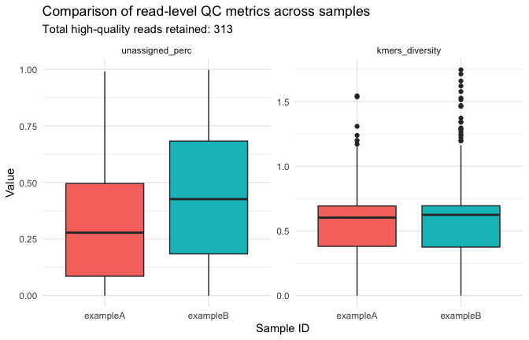

```r
plot_data <- melt(
  as.data.table(combined_qc),
  id.vars = "sample_id",
  measure.vars = c("unassigned_perc", "kmers_diversity"),
  variable.name = "metric",
  value.name = "value"
)

ggplot(plot_data, aes(x = sample_id, y = value, fill = sample_id)) +
  geom_boxplot() +
  facet_wrap(~metric, scales = "free_y") +
  theme_minimal() +
  labs(
    title = "Comparison of read-level QC metrics across samples",
    subtitle = paste(
      "Total high-quality reads retained:",
      sum(lengths(hq_reads_list))
    ),
    x = "Sample ID",
    y = "Value"
  ) +
  theme(legend.position = "none")
```

## 2. Species-level abundance estimation

After defining a read-level QC filter, BASEN can estimate genome-size-aware species-level relative abundance using the retained reads.

### A. Calculate relative abundance

- The `kraken_relative_abundance()` function aggregates species-assigned k-mer evidence across classified reads, normalizes this signal by effective reference genome length, and scales the resulting coverage proxies within each sample to generate relative abundance estimates.
- If a read filter is provided, only retained reads contribute to abundance estimation.
- Interpretation of the output columns:
  1. `bases_assigned`: total number of species-assigned k-mers
  2. `reads_assigned`: number of reads assigned to the species
  3. `genome_size_bp`: effective reference genome size used for normalization
  4. `coverage_proxy`: genome-length-normalized sequencing signal
  5. `relative_abundance`: within-sample normalized species-level abundance

```r
ra_dt <- kraken_relative_abundance(
  report_dir = kraken_dir,
  kraken_dir = kraken_dir,
  genome_stats_file = genome_stats_file,
  read_filter = hq_reads_list,
  verbose = TRUE
)
```

```
#> No output_folder specified. Writing results to: vignettes
#> Processing 2 sample(s).
#> Processing sample: exampleA
#>  - Reads after applying quality filter: 84
#> Processing sample: exampleB
#>  - Reads after applying quality filter: 229
#> Execution statistics for kraken_relative_abundance:
#> Total samples processed: 2
#> Total files read: 4
```

```r
head(ra_dt)
```

```
#>    sample_id                            name   taxid genome_size_bp
#>       <char>                          <char>  <char>          <num>
#> 1:  exampleA              Bacteroides ovatus   28116        6472455
#> 2:  exampleA         Sellimonas intestinalis 1653434        3189018
#> 3:  exampleA                  Blautia faecis  871665        4104642
#> 4:  exampleA    Coprococcus intestinihominis 3133154        3604694
#> 5:  exampleA Fusicatenibacter saccharivorans 1150298        3782769
#> 6:  exampleA          Faecalibacillus faecis 1982628        2525912
#>    bases_assigned reads_assigned coverage_proxy relative_abundance
#>             <num>          <int>          <num>              <num>
#> 1:           2291              9   3.539615e-04         0.34951758
#> 2:           1058              3   3.317636e-04         0.32759833
#> 3:            407              5   9.915603e-05         0.09791114
#> 4:            192              1   5.326388e-05         0.05259516
#> 5:            126              1   3.330893e-05         0.03289074
#> 6:             82              1   3.246352e-05         0.03205595
```

### B. Export per-sample results (optional)

- BASEN can optionally write one `*.basen` file per sample to disk.

```r
kraken_relative_abundance(
  report_dir = kraken_dir,
  kraken_dir = kraken_dir,
  genome_stats_file = genome_stats_file,
  read_filter = hq_reads_list,
  output_folder = "relative_abundance_results"
)
```

```
#> Created output folder: relative_abundance_results
#> Processing 2 sample(s).
#> Processing sample: exampleA
#>  - Reads after applying quality filter: 84
#> Processing sample: exampleB
#>  - Reads after applying quality filter: 229
#> Execution statistics for kraken_relative_abundance:
#> Total samples processed: 2
#> Total files read: 4
#>     sample_id                            name   taxid genome_size_bp
#>        <char>                          <char>  <char>          <num>
#>  1:  exampleA              Bacteroides ovatus   28116        6472455
#>  2:  exampleA         Sellimonas intestinalis 1653434        3189018
#>  3:  exampleA                  Blautia faecis  871665        4104642
#>  4:  exampleA    Coprococcus intestinihominis 3133154        3604694
```

[output cut: 60 more lines]

### C. Aggregate per-sample outputs (optional)

- If results were exported as per-sample `*.basen` files, `collect_basen_metrics()` can be used to collect relative abundance, coverage proxy, or both into a single long-format table.

```r
ra_combined <- collect_basen_metrics(
  output_folder = "relative_abundance_results",
  metric = "relative_abundance"
)
```

```
#> Execution statistics for collect_basen_metrics:
#> Total files read: 2
#> Total samples processed: 2
#> Total rows aggregated: 29
```

```r
cp_combined <- collect_basen_metrics(
  output_folder = "relative_abundance_results",
  metric = "coverage_proxy"
)
```

```
#> Execution statistics for collect_basen_metrics:
#> Total files read: 2
#> Total samples processed: 2
#> Total rows aggregated: 29
```

### D. Convert long-format output to a matrix

- For downstream analyses, the BASEN output can be reshaped into a wide matrix. Below, a sample-by-taxon matrix is generated using `coverage_proxy` values.

```r
ra_mat_dt <- dcast(
  ra_dt,
  sample_id ~ taxid,
  value.var = "coverage_proxy",
  fill = 0
)

head(ra_mat_dt[, 1:4])
```

```
#> Key: <sample_id>
#>    sample_id      1150298      1638786      1653434
#>       <char>        <num>        <num>        <num>
#> 1:  exampleA 3.330893e-05 0.000000e+00 3.317636e-04
#> 2:  exampleB 3.833171e-05 8.083681e-05 8.529271e-05
```

```r
ra_mat <- as.matrix(ra_mat_dt[, -1, with = FALSE])
rownames(ra_mat) <- ra_mat_dt$sample_id

head(ra_mat[, 1:3])
```

```
#>               1150298      1638786      1653434
#> exampleA 3.330893e-05 0.000000e+00 3.317636e-04
#> exampleB 3.833171e-05 8.083681e-05 8.529271e-05
```

## 3. Cross-sample normalization

BASEN also provides an optional utility for estimating sample-specific size factors from coverage-proxy matrices to support downstream cross-sample normalization. This step is not part of the core BASEN abundance-estimation procedure, but may be useful for comparative analyses across samples with different sequencing depths.

### A. Calculate size factors

- The `calc_size_factors()` function implements a median-ratio normalization strategy. It constructs a reference across taxa, computes per-sample ratios relative to that reference, and summarizes those ratios into sample-specific size factors. This approach is more robust to highly abundant taxa than simple total-sum scaling.
- Importantly, size factors should be calculated from `coverage_proxy` values rather than `relative_abundance`, because relative abundance is already compositional and does not retain the total-depth signal required for this normalization step.

```r
abundance_mat <- dcast(
  ra_dt,
  taxid ~ sample_id,
  value.var = "coverage_proxy",
  fill = 0
)

coverage_mat <- as.matrix(abundance_mat[, -1, with = FALSE])
rownames(coverage_mat) <- abundance_mat$taxid

sf_median <- calc_size_factors(
  x = coverage_mat,
  method = "median"
)
```

```
#> Execution statistics for calc_size_factors:
#> Total matrices processed: 1
#> Taxa used for reference: 6
#> Size factors calculated: 2
```

```r
print(sf_median)
```

```
#>  exampleA  exampleB
#> 1.0138142 0.9928107
```

### B. Apply normalization

- Once the size factors are calculated, a normalized coverage-proxy matrix can be obtained by dividing each sample by its corresponding size factor.

```r
normalized_mat <- sweep(coverage_mat, 2, sf_median, "/")
head(normalized_mat)
```

```
#>             exampleA     exampleB
#> 1150298 3.285507e-05 3.860928e-05
#> 1638786 0.000000e+00 8.142217e-05
#> 1653434 3.272430e-04 8.591035e-05
#> 1872531 9.685774e-07 0.000000e+00
#> 1982628 3.202118e-05 0.000000e+00
#> 2211183 1.937654e-05 2.366300e-04
```